# Explora Métricas para Trabajo de Encuestas

## Introducción

El trabajo de campo es fundamental para estimar la preferencia de los ciudadanos, y en particular de los votantes, es decir, de los ciudadanos que realmente omitirán su voto el día de la elección. Es importante contar con una métrica que nos indique el cumplimiento, la calidad o validez de la información que reportan los equipos de encuestadores.

La encuestadora DPD tiene a dos personas encargadas de planear, administrar y monitorear el trabajo de campo, y además capturar la información recopilada. La Lic. Beatriz Sierra se encarga de la contratación y pago del personal, revisión de formatos de encuestas, gafetes o identificaciones, captura y auditoría de las encuestas; y el M. en C. Fidel Lozano se encarga de la logística, como generación de muestras, formación de equipos, rutas, mapas, hojas de control, análisis de resultados y generación de reportes. En general los pasos que realizan, una vez que se tiene un ejercicio o encuesta, para el trabajo de campo son:  
1. Generación de una muestra (combinación de un muestreo PPT, Estratificado, Sistemático y por cuota).  
2. Mapeo del ejercicio y generación de rutas.  
3. Formación de equipos.  
4. Supervisores contactan a su equipo y les dan indicaciones.  
5. Generación e impresión de hojas de control.  
6. Entrega de material a los supervisores un día antes (noche) o muy temprano antes de salir en su ruta.  
7. Supervisores recogen a su equipo y los trasladan a cada sitio programado (sección electoral).  
8. Supervisores entregan formatos y encuestas realizadas (al final del día o jornada).  
9. Equipo de capturistas recolecta la información usando Lime Survey.  
10. Un equipo de dos o tres capturistas más capacitadas realiza la auditoría de la base (limpieza de datos). La base final se entrega en un archivo SPSS.  
11. Se realiza el análisis estadístico, incluyendo en método de eliminación de incongruencias (MEI).

## Equipos de trabajo

```r
trackzac %>%
  group_by(Fecha,Supervisor) %>%
  summarise(Encuestas = n(),
            Encuestadores = length(unique(Enc))
            ) %>%
  datatable()
```

|  | Fecha | Supervisor | Encuestas | Encuestadores |
| --- | --- | --- | --- | --- |
| 1 | 2021-03-14 | Artemio | 145 | 4 |
| 2 | 2021-03-14 | César | 156 | 6 |
| 3 | 2021-03-14 | Gonzalo | 156 | 3 |
| 4 | 2021-03-14 | Miguel | 84 | 5 |
| 5 | 2021-03-14 | Mirna | 156 | 6 |
| 6 | 2021-03-14 | Rafael | 156 | 4 |
| 7 | 2021-03-14 | Ricardo | 156 | 4 |
| 8 | 2021-03-19 | Artemio | 84 | 3 |
| 9 | 2021-03-19 | César | 72 | 3 |
| 10 | 2021-03-19 | Gonzalo | 84 | 4 |

[output cut: 23 more lines]

## Rechazos a la entrevista

De acuerdo a los lineamientos del Instituto Nacional Electoral, Anexo 3 (INE, 2021), para sondeos de opinión se requiere reportar la frecuencia de no respuesta y la tasa de rechazo general a la entrevista.

En cada encuesta completada en DPD se registra el número de rechazos hasta obtener la encuesta. No se registra si es rechazo por negación del posible encuestado o por no corresponder al perfil de la cuota.

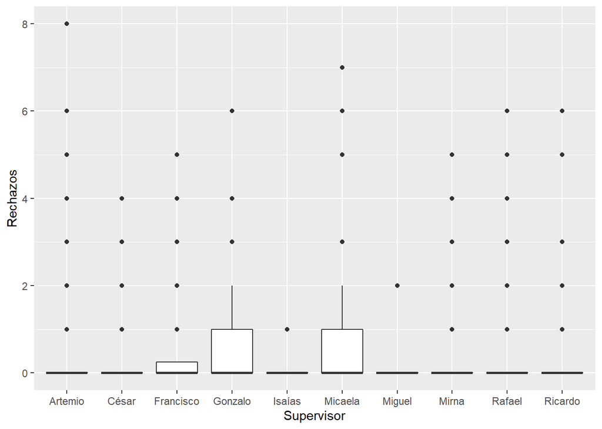

```r
ggplot(trackzac, aes(x=Supervisor, y =Rechazos)) +
  geom_boxplot()
```

```r
trackzac %>%
  group_by(Supervisor) %>%
  summarise(n = n(),
            min = min(Rechazos),
            mean = mean(Rechazos),
            sd = sd(Rechazos),
            max = max(Rechazos)
            ) %>%
  print()
```

```
## # A tibble: 10 x 6
##    Supervisor     n   min   mean    sd   max
##    <chr>      <int> <dbl>  <dbl> <dbl> <dbl>
##  1 Artemio      481     0 0.353  0.942     8
##  2 César        444     0 0.264  0.672     4
##  3 Francisco     96     0 0.458  0.972     5
##  4 Gonzalo      504     0 0.407  0.812     6
##  5 Isaías        24     0 0.167  0.381     1
##  6 Micaela       84     0 0.881  1.53      7
##  7 Miguel        84     0 0.0238 0.218     2
##  8 Mirna        480     0 0.227  0.600     5
##  9 Rafael       503     0 0.256  0.765     6
## 10 Ricardo      324     0 0.358  0.848     6
```

## No Respuesta

Una preocupación en la realización de la entrevista es la alta no respuesta, que puede sesgar las estimaciones. La definición de No Respuesta es muy variada, pero en este documento se considera el “No sé”.

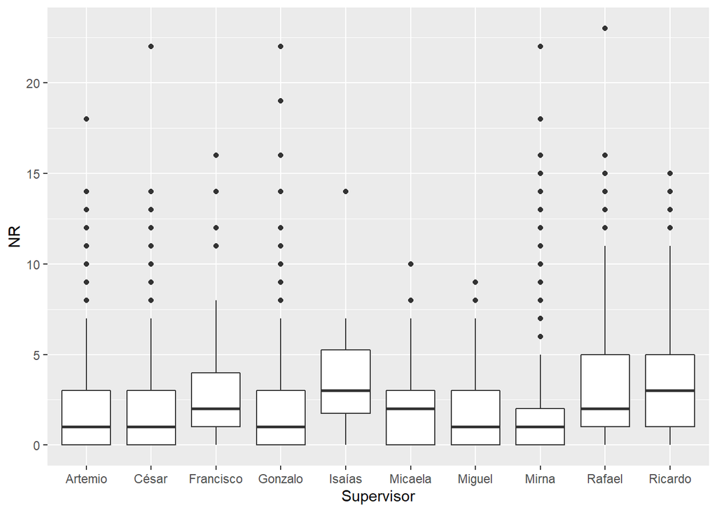

```r
ggplot(trackzac, aes(x=Supervisor, y=NR)) +
  geom_boxplot()
```

```r
trackzac %>%
  group_by(Supervisor) %>%
  summarise(Encuestas = n(),
            min = min(NR),
            mean = mean(NR),
            sd = sd(NR),
            max = max(NR))
```

```
## # A tibble: 10 x 6
##    Supervisor Encuestas   min  mean    sd   max
##    <chr>          <int> <int> <dbl> <dbl> <int>
##  1 Artemio          481     0  1.89  2.48    18
##  2 César            444     0  2.15  2.81    22
##  3 Francisco         96     0  3     3.18    16
##  4 Gonzalo          504     0  2.01  2.87    22
##  5 Isaías            24     0  3.71  3.11    14
##  6 Micaela           84     0  2.01  2.23    10
##  7 Miguel            84     0  1.85  1.95     9
##  8 Mirna            480     0  1.92  3.04    22
##  9 Rafael           503     0  3.27  3.41    23
## 10 Ricardo          324     0  3.32  2.85    15
```

## Cuotas

El esquema de muestreo de DPD requiere que en cada sección electoral se incluya una cuota por sexo y edad proporcional a los registros correspondiente de la lista nominal. En particular para el estadado las cuotas tienen la siguiente proporción.

```r
dbedad %>%
  mutate(EDAD = factor(EDAD, levels = 1:4, labels = c("18 a 29 años",
                     "30 a 44 años", "45 a 59 años", "60 o más años"))) %>%
  group_by(EDAD) %>%
  summarise(Lista_Nominal = sum(LISTA.NOMINAL),
            Porcentaje = Lista_Nominal/sum(dbedad$LISTA.NOMINAL)*100)
```

```
## # A tibble: 4 x 3
##   EDAD          Lista_Nominal Porcentaje
##   <fct>                 <dbl>      <dbl>
## 1 18 a 29 años         320814       27.9
## 2 30 a 44 años         338758       29.5
## 3 45 a 59 años         268274       23.3
## 4 60 o más años        221576       19.3
```

```r
dbsexo %>%
  mutate(SEXO = factor(SEXO, levels = 1:2, labels = c("Hombre", "Mujer"))) %>%
  group_by(SEXO) %>%
  summarise(Lista_Nominal = sum(LISTA.NOMINAL),
            Porcentaje = Lista_Nominal/sum(dbsexo$LISTA.NOMINAL)*100)
```

```
## # A tibble: 2 x 3
##   SEXO   Lista_Nominal Porcentaje
##   <fct>          <dbl>      <dbl>
## 1 Hombre        556651       48.4
## 2 Mujer         592771       51.6
```

Las coutas obtenidas por cada supervisor o equipo se muestran a continuación.

```r
ledad <- levels(trackzac$p1)
trackzac %>%
  group_by(Supervisor) %>%
  summarise(n = n(),
            porc_18_29 = sum(p1 == ledad[1])/n*100,
            porc_30_44 = sum(p1 == ledad[2])/n*100,
            porc_45_59 = sum(p1 == ledad[3])/n*100,
            porc_60_mas = sum(p1 == ledad[4])/n*100) %>%
  print()
```

```
## # A tibble: 10 x 6
##    Supervisor     n porc_18_29 porc_30_44 porc_45_59 porc_60_mas
##    <chr>      <int>      <dbl>      <dbl>      <dbl>       <dbl>
##  1 Artemio      481       28.7       29.9       22.2        19.1
##  2 César        444       24.8       29.5       24.8        20.9
##  3 Francisco     96       29.2       26.0       25          19.8
##  4 Gonzalo      504       29.0       31.9       21.4        17.7
##  5 Isaías        24       20.8       25         20.8        33.3
##  6 Micaela       84       22.6       21.4       27.4        28.6
##  7 Miguel        84       32.1       33.3       19.0        15.5
##  8 Mirna        480       27.3       32.1       21.0        19.6
##  9 Rafael       503       29.0       30.2       21.1        19.7
## 10 Ricardo      324       27.8       29.6       22.5        20.1
```

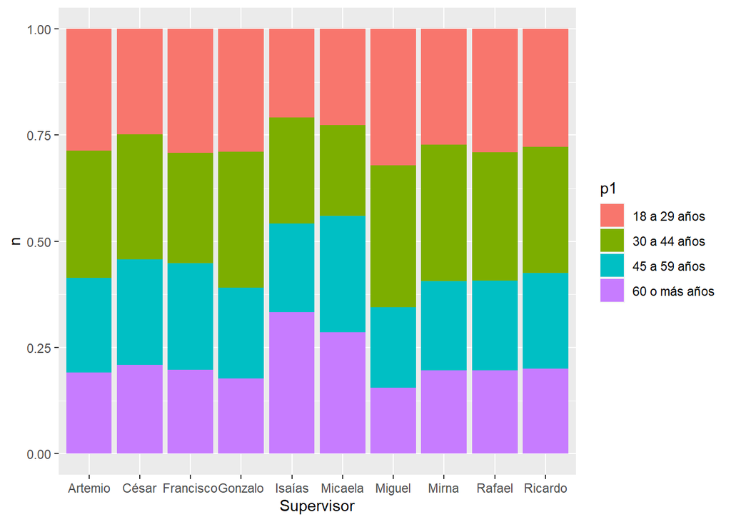

```r
trackzac %>%
  group_by(Supervisor, p1) %>%
  summarise(n = n()) %>%
  ggplot(aes(fill=p1, y=n, x=Supervisor)) +
  geom_bar(position="fill", stat="identity")
```

```r
trackzac %>%
  group_by(Supervisor) %>%
  summarise(n = n(),
            Hombres = sum(p2 == "Hombre"),
            Mujeres = sum(p2 == "Mujer"),
            porc_Hombres = Hombres/n*100,
            porc_Mujeres = Mujeres/n*100)
```

```
## # A tibble: 10 x 6
##    Supervisor     n Hombres Mujeres porc_Hombres porc_Mujeres
##    <chr>      <int>   <int>   <int>        <dbl>        <dbl>
##  1 Artemio      481     212     269         44.1         55.9
##  2 César        444     206     238         46.4         53.6
##  3 Francisco     96      37      59         38.5         61.5
##  4 Gonzalo      504     232     272         46.0         54.0
##  5 Isaías        24      11      13         45.8         54.2
##  6 Micaela       84      32      52         38.1         61.9
##  7 Miguel        84      33      51         39.3         60.7
##  8 Mirna        480     220     260         45.8         54.2
##  9 Rafael       503     217     286         43.1         56.9
## 10 Ricardo      324     150     174         46.3         53.7
```

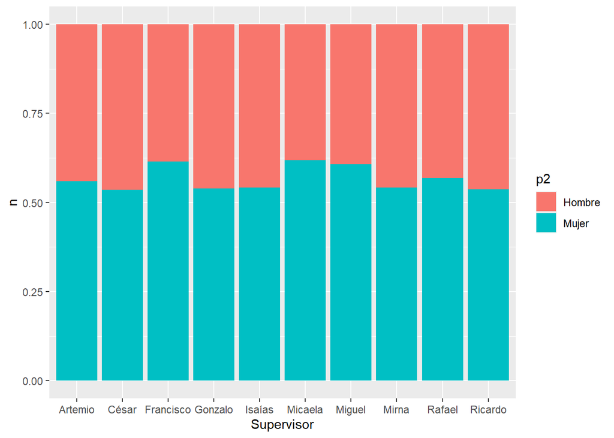

```r
trackzac %>%
  group_by(Supervisor, p2) %>%
  summarise(n = n()) %>%
  ggplot(aes(fill=p2, y=n, x=Supervisor)) +
  geom_bar(position="fill", stat="identity")
```

## Método de Eliminación de Incongruencias

La encuestadora DPD ha desarrollado un método heurístico para eliminar del análisis aquellas encuestas que no sean confiables o incongruentes con la información que se recolecta. En general se observan los siguientes aspectos:  
1. Incongruencia en el desempeño del presidente. Se pregunta al encuestado si aprueba mucho su trabajo realizado, y si pide una calificación del 0 al 10. Si el encuestado contesta que “Aprueba mucho”, pero lo califica con 5 o menos, se considera una incongruencia.  
2. Incongruencia en el desempeño del gobernador. Similar al anterior.  
3. Incongruencia en la preferencia del partido. Se pregunta al encuestado con qué partido se identifica más, y también por cuál partido nunca votaría. Si en las dos preguntas responde con el mismo partido, se considera una incongruencia.  
4. Alta no respuesta. Considerando solamente las preguntas que necesariamente se deben contestar, no se incluyen preguntas opcionales, se clasifican los casos con más no respuesta como encuestas incongruentes.

Todas las encuestas con incongruencias se eliminan del análisis estadístico del ejercicio.

```
ggplot(trackzac, aes(x=Supervisor, y=MEI_1_3)) +
  geom_boxplot()
trackzac %>%
  group_by(Supervisor) %>%
  summarise(n = n(),
            mei13 = sum(MEI_1_3),
            mean = mean(MEI_1_3),
            sd = sd(MEI_1_3))
```

## Tiempo de la Entrevista

```r
ErrEnc <- trackzac %>%
  group_by(Supervisor, ErrEnctime) %>%
  summarise(n = n())
print(ErrEnc)
```

```
## # A tibble: 28 x 3
## # Groups:   Supervisor [10]
##    Supervisor ErrEnctime          n
##    <chr>      <fct>           <int>
##  1 Artemio    Tiempo en rango   444
##  2 Artemio    Negativo           26
##  3 Artemio    Demasiado          11
##  4 César      Tiempo en rango   416
##  5 César      Negativo           19
##  6 César      Demasiado           9
##  7 Francisco  Tiempo en rango    95
##  8 Francisco  Negativo            1
##  9 Gonzalo    Tiempo en rango   489
## 10 Gonzalo    Negativo            8
## # ... with 18 more rows
```

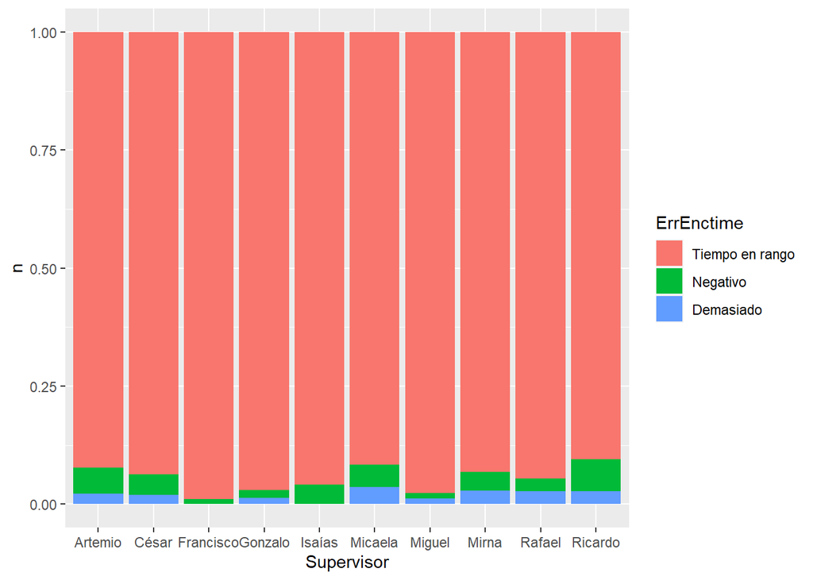

```r
ggplot(ErrEnc, aes(fill=ErrEnctime, y=n, x=Supervisor)) +
  geom_bar(position="fill", stat="identity")
```

[figure not shown]

```r
filter(trackzac, ErrEnctime == "Tiempo en rango") %>%
  ggplot(aes(x=Sup, y=Enctime)) + geom_boxplot()
```

```r
filter(trackzac, ErrEnctime == "Tiempo en rango") %>%
  group_by(Supervisor) %>%
  summarise(n = n(),
            mean = mean(Enctime),
            sd = sd(Enctime))
```

```
## # A tibble: 10 x 4
##    Supervisor     n  mean    sd
##    <chr>      <int> <dbl> <dbl>
##  1 Artemio      444  7.87  2.95
##  2 César        416  7.05  2.76
##  3 Francisco     95  8.13  2.38
##  4 Gonzalo      489  7.40  3.07
##  5 Isaías        23  5.91  1.95
##  6 Micaela       77  8.66  3.19
##  7 Miguel        82  7.73  2.10
##  8 Mirna        447  8.36  3.20
##  9 Rafael       476  7.14  2.48
## 10 Ricardo      293  6.45  2.98
```

## Referencias

INE (24 de abril de 2021). Reglamento de Elecciones. https://www.ine.mx/normatividad-vigente-materia-encuestas-electorales/